# Healthcare

Adriana and Elisa

# Introduction

In this project we used the data from the Henry J Kaiser Family Foundation (KFF). In particular we used Health Insurance Coverage of the Total Population for the years 2013-2016 and Health Care Expenditures by State of Residence (in millions) for the years 1991-2014.

In this project we studied the data for the years 2013 and 2014. We first looked at which are the states that spent the most money in 2013 on health insurances and plotted the results in a bar plot. California is the state that spent the most on health insurances that year, followed by New Yoork and Texas. We then produced a similar graph for the year 2014. We discovered that the ranking of the states in terms of money spent on health insurances is the same as in 2013. Finally, we produced a comparison bar plot for the years 2013 and 2014 and we compared the amount of money spent by the different states on health insurances. It appears that every state we considered increased the amount of money spent on health insurance in 2014.

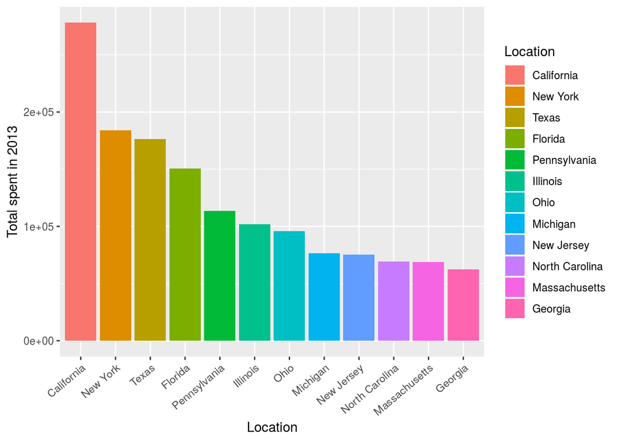

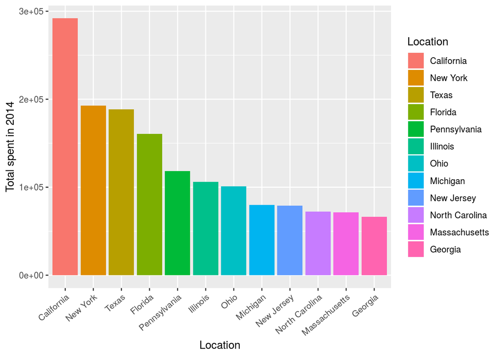

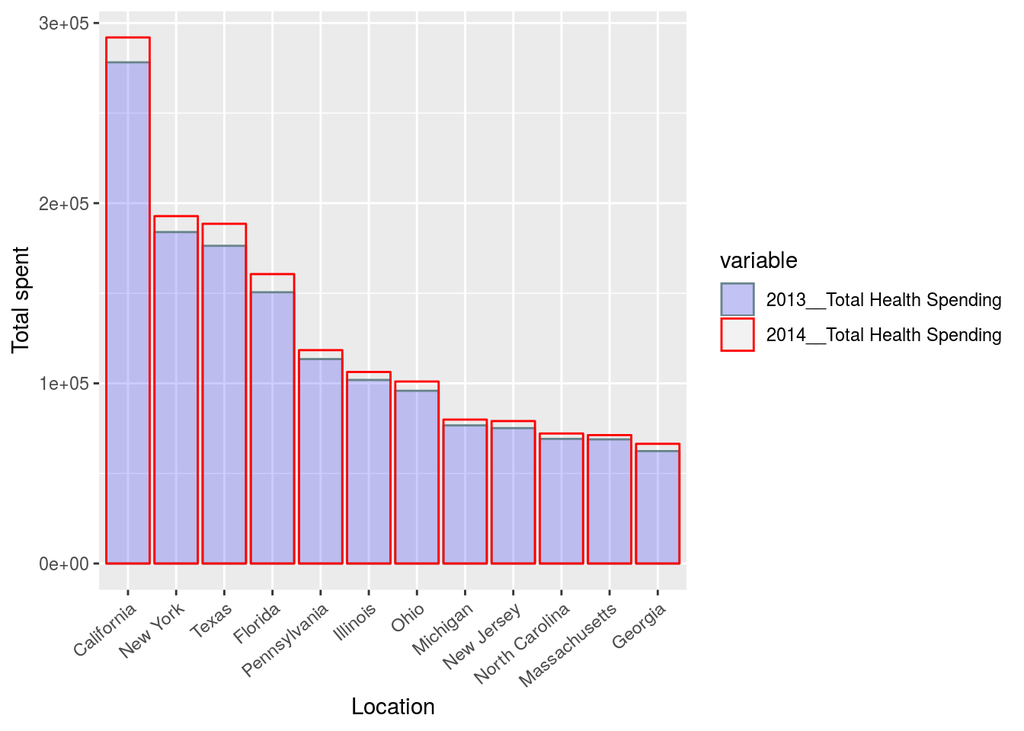

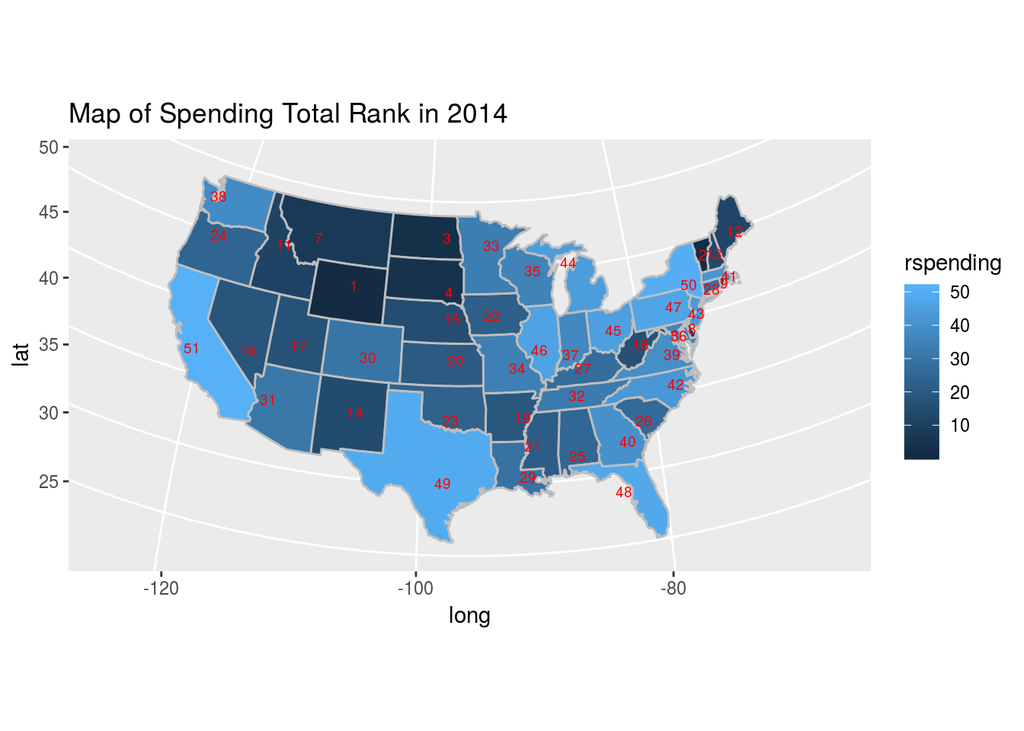

Creating the map

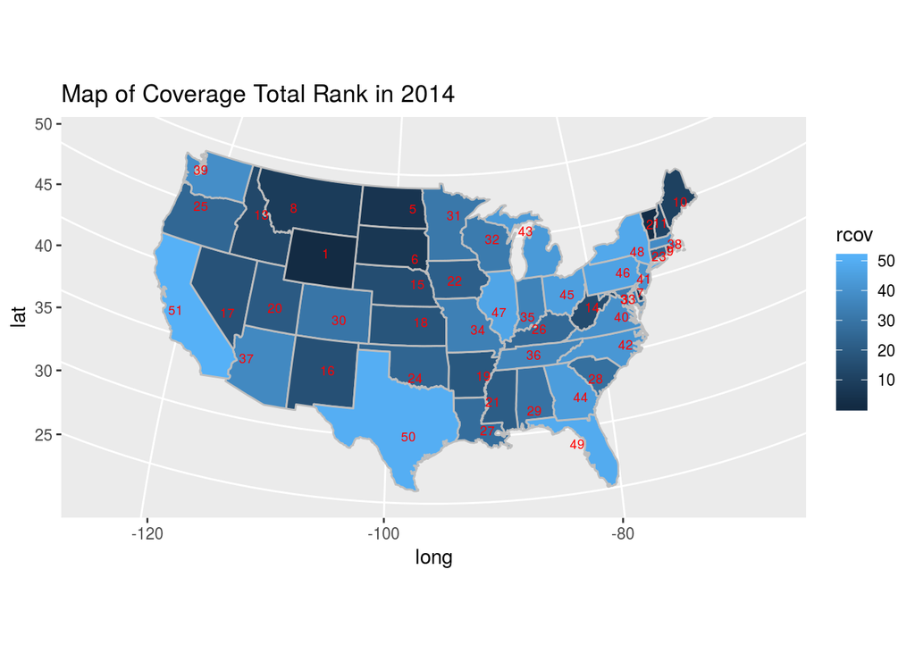

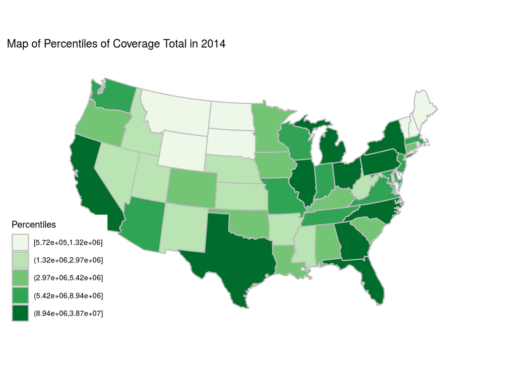

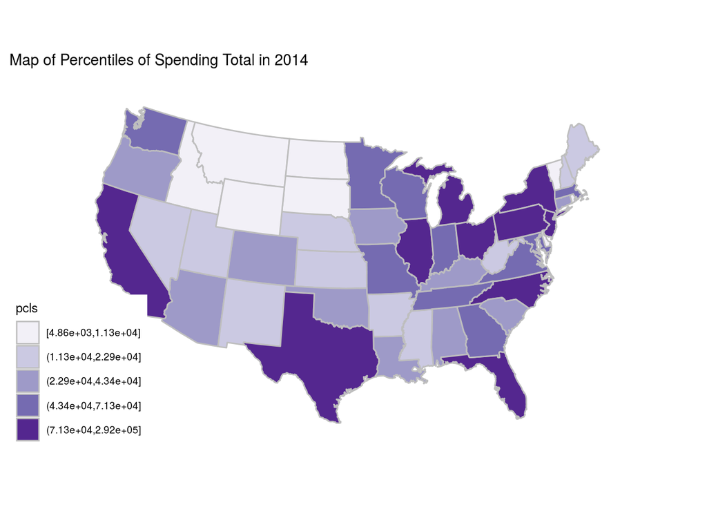